# **Homework Assignment 3 (100 points total)**

### **Assigned at the start of Module 9**

### **Due at the end of Module 12**

# Q1: Supervised Learning Regression

## Build a supervised learning linear regression model (scikit-learn permitted) (30 points total)

In this question, you will analyze a housing dataset and investigate the impact of multicollinearity on a Linear Regression model. You will then apply Ridge and Lasso Regression to mitigate these effects and compare their performance.

### **1. Data Acquisition & Preprocessing (5 points)**

- **Dataset** Use the California Housing Dataset (available via `sklearn.datasets`).
- **Exploratory Data Analysis (EDA):**
  - Identify and describe the feature distributions.
  - Check for multicollinearity using a correlation heatmap and Variance Inflation Factor (VIF).
  - Select a subset of features that introduce multicollinearity.
- **Preprocessing**:
  - Standardize the dataset to ensure consistent scaling.
  - Split the data into training (80%) and testing (20%) sets.

```
Descriptive Stats:
```

|  | MedInc | HouseAge | AveRooms | AveBedrms | Population | AveOccup | Latitude | Longitude | MedHouseVal |
| --- | --- | --- | --- | --- | --- | --- | --- | --- | --- |
| count | 20640.000000 | 20640.000000 | 20640.000000 | 20640.000000 | 20640.000000 | 20640.000000 | 20640.000000 | 20640.000000 | 20640.000000 |
| mean | 3.870671 | 28.639486 | 5.429000 | 1.096675 | 1425.476744 | 3.070655 | 35.631861 | -119.569704 | 2.068558 |
| std | 1.899822 | 12.585558 | 2.474173 | 0.473911 | 1132.462122 | 10.386050 | 2.135952 | 2.003532 | 1.153956 |
| min | 0.499900 | 1.000000 | 0.846154 | 0.333333 | 3.000000 | 0.692308 | 32.540000 | -124.350000 | 0.149990 |
| 25% | 2.563400 | 18.000000 | 4.440716 | 1.006079 | 787.000000 | 2.429741 | 33.930000 | -121.800000 | 1.196000 |
| 50% | 3.534800 | 29.000000 | 5.229129 | 1.048780 | 1166.000000 | 2.818116 | 34.260000 | -118.490000 | 1.797000 |
| 75% | 4.743250 | 37.000000 | 6.052381 | 1.099526 | 1725.000000 | 3.282261 | 37.710000 | -118.010000 | 2.647250 |
| max | 15.000100 | 52.000000 | 141.909091 | 34.066667 | 35682.000000 | 1243.333333 | 41.950000 | -114.310000 | 5.000010 |

```
Feature Distributions:
```

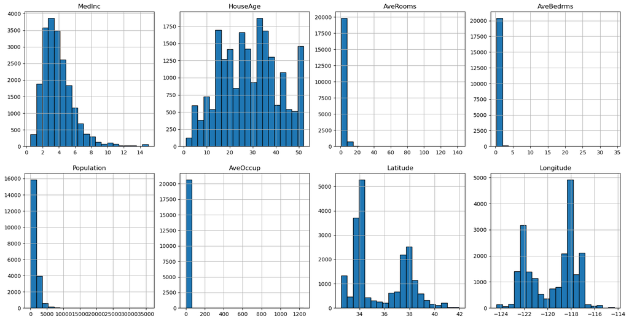

```
Missing Values:
```

```
MedInc         0
HouseAge       0
AveRooms       0
AveBedrms      0
Population     0
AveOccup       0
Latitude       0
Longitude      0
MedHouseVal    0
dtype: int64
```

```
Heatmap:
```

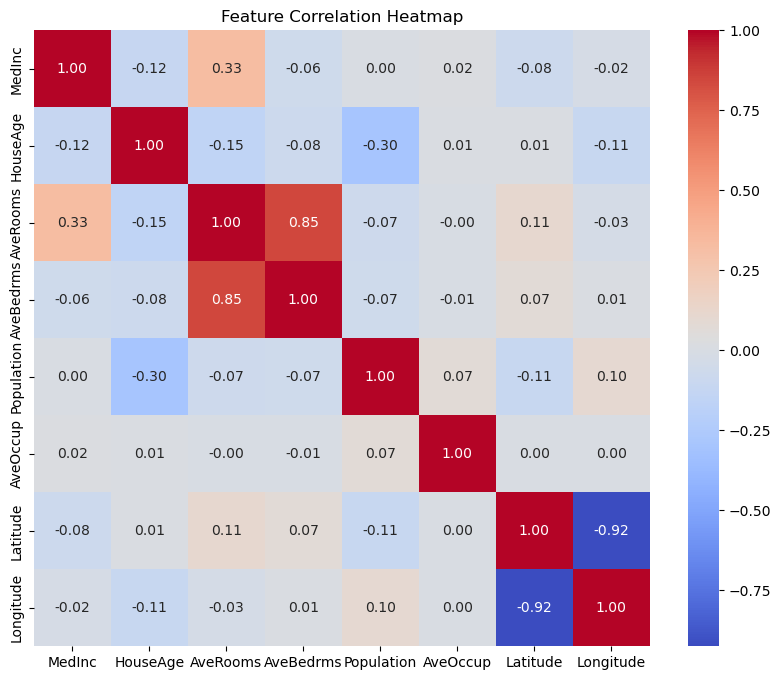

```
VIF:
```

|  | Feature | VIF |
| --- | --- | --- |
| 0 | MedInc | 11.511140 |
| 1 | HouseAge | 7.195917 |
| 2 | AveRooms | 45.993601 |
| 3 | AveBedrms | 43.590314 |
| 4 | Population | 2.935745 |
| 5 | AveOccup | 1.095243 |
| 6 | Latitude | 559.874071 |
| 7 | Longitude | 633.711654 |

```python
# Calfiornia Housing Dataset
from sklearn.datasets import fetch_california_housing
import pandas as pd
import numpy as np
import matplotlib.pyplot as plt
import seaborn as sns
from sklearn.preprocessing import StandardScaler
from statsmodels.stats.outliers_influence import variance_inflation_factor
from sklearn.model_selection import train_test_split

housing_data = fetch_california_housing()
housing_df = pd.DataFrame(housing_data['data'], columns=housing_data['feature_names'])
housing_df[housing_data['target_names'][0]] = housing_data['target']

# --- Exploratory Data Analysis ---
# Descriptive statistics and feature distributions
print("Descriptive Stats:")
display(housing_df.describe())

print("Feature Distributions:")
fig, axes = plt.subplots(nrows=2, ncols=4, figsize=(20, 10))
axes = axes.flatten()
for i, column in enumerate(housing_df.columns):
    if i < len(axes):
        housing_df[column].hist(ax=axes[i], bins=20, edgecolor='black')
        axes[i].set_title(f'{column}')
plt.show()

print("Missing Values:")
display(housing_df.isna().sum())

# Correlation Heatmap
print("Heatmap:")
target = housing_df['MedHouseVal']
features = housing_df.drop(columns='MedHouseVal')
corr_matrix = features.corr()
plt.figure(figsize=(10, 8))
sns.heatmap(corr_matrix, annot=True, cmap='coolwarm', fmt=".2f", square=True)
plt.title("Feature Correlation Heatmap")
plt.show()

# VIF
print("VIF:")
vif_data = pd.DataFrame()
vif_data["Feature"] = features.columns
vif_data["VIF"] = [variance_inflation_factor(features.values, i) for i in range(features.shape[1])]
display(vif_data)

# --- Preprocessing ---
# Standardize data
scaler = StandardScaler()
features_scaled = pd.DataFrame(scaler.fit_transform(features), columns=features.columns)

# Split into train and test sets
x_train, x_test, y_train, y_test = train_test_split(features_scaled, target, test_size=0.2, random_state=42)
```

From the above, we can see that the data in the California Housing dataset is all numeric. There are 8 independent variables and 1 dependent target varible. The 8 independent variables include median income, median house age, average number of rooms per house, average number of bedrooms per house, population, average number of household members, latitude, and longitude. None of the data is missing. Also, based on the feature distribution histograms, none of the features (independent variabels) are normally distributed. Median income, avg rooms, avg bedrooms, population, and avg occup are all skewed right. Latitude and Longitude are bimodal.

We can also check for multicollinearity using the VIF. Here, VIF = 1 indicates no multicollinearity, VIF > 5 indicates some multicollinearity, and VIF > 10 indicates very high multicollinearity. We should conider removing features with VIF > 10. MedInc, AveRooms, AveBedrms, Latitude, and Longitude all have very large VIF values, and we should consider removing them from our dataset.

This question asks "Select a subset of features that introduce multicollinearity." The dataset as it is does introduce multicollinearity, so I will continue this problem with the full set. If we wanted a subset of features where all features introduce multicollinearity, we should select MedInc, Latitude, Longitude, AveRooms, and AveBedrms. If we wanted to remove multicollinearity, we should exclude these features, especially latitude and longitude.

### 2. **Regression Model Development (10 points)**

- **Train a Linear Regression Model:**
  - Fit a standard Linear Regression model to the data.
  - Report the coefficients and explain their significance.
  - Evaluate the model using MSE, RMSE, and $R^2$.
- **Detect Multicollinearity Issues:**
  - Identify unstable coefficients or unusually large magnitudes in the model.
  - Explain how multicollinearity affects interpretation.

```python
# --- Train Linear Regression Model ---
# Fit standard LR model to the data
import numpy as np
from sklearn.linear_model import LinearRegression
from sklearn.metrics import mean_squared_error, r2_score
model = LinearRegression()
model.fit(x_train, y_train)

# Report coefficients
print('Model Coefficients and Intercept:')
coefficients = pd.DataFrame({
    'Feature': features_scaled.columns,
    'Coefficient': model.coef_
})
display(coefficients)
intercept = print(f"Intercept: {model.intercept_:.4f}\n")

# Evaluate model with MSE, RMSE, and R2
y_pred = model.predict(x_test)
mse = mean_squared_error(y_test, y_pred)
rmse = np.sqrt(mse)
r2 = r2_score(y_test, y_pred)

print(f"Mean Squared Error (MSE): {mse:.4f}")
print(f"Root Mean Squared Error (RMSE): {rmse:.4f}")
print(f"R-squared (R^2): {r2:.4f}")

# --- Detect Multicollinearity Issues ---
coefficients['Abs_Coefficient'] = coefficients['Coefficient'].abs()
unstable_coeffs = coefficients.sort_values(by='Abs_Coefficient', ascending=False)
# display(unstable_coeffs)

# display(vif_data)
x = vif_data.merge(unstable_coeffs, on='Feature')
x.sort_values(by='Abs_Coefficient', ascending=False)
```

```
Model Coefficients and Intercept:
```

|  | Feature | Coefficient |
| --- | --- | --- |
| 0 | MedInc | 0.852382 |
| 1 | HouseAge | 0.122382 |
| 2 | AveRooms | -0.305116 |
| 3 | AveBedrms | 0.371132 |
| 4 | Population | -0.002298 |
| 5 | AveOccup | -0.036624 |
| 6 | Latitude | -0.896635 |
| 7 | Longitude | -0.868927 |

```
Intercept: 2.0679

Mean Squared Error (MSE): 0.5559
Root Mean Squared Error (RMSE): 0.7456
R-squared (R^2): 0.5758
```

|  | Feature | VIF | Coefficient | Abs_Coefficient |
| --- | --- | --- | --- | --- |
| 6 | Latitude | 559.874071 | -0.896635 | 0.896635 |
| 7 | Longitude | 633.711654 | -0.868927 | 0.868927 |
| 0 | MedInc | 11.511140 | 0.852382 | 0.852382 |
| 3 | AveBedrms | 43.590314 | 0.371132 | 0.371132 |
| 2 | AveRooms | 45.993601 | -0.305116 | 0.305116 |
| 1 | HouseAge | 7.195917 | 0.122382 | 0.122382 |
| 5 | AveOccup | 1.095243 | -0.036624 | 0.036624 |
| 4 | Population | 2.935745 | -0.002298 | 0.002298 |

Based on the model coefficients, none are extremely large or unstable. The features that do have the largest coefficients do have the highest VIF values, which indicates that they may be unstable and are affected by multicollinearity.

Multicollinearity affects interpretation in that it makes it difficult to tell which features are actually important/which features contribute the most to the model. For example, Latitude and Longitude are highly correlated, have a high VIF score, and have the largest coefficient magnitudes. All of these points indicate that these features introduce multicollinearity. Because of this, we will be unable to tell which of Latitude or Longitude is contributing to the model's performance becuase they are so coupled with one another.

### **3. Regularization Techniques: Ridge vs. Lasso (10 points)**

- **Apply Ridge Regression (L2 Regularization):**
  - Train a Ridge model with various values of $\lambda$(e.g., 0.1, 1, 10, 100).
  - Plot coefficient shrinkage as $\lambda$ increases.
  - Evaluate model performance using MSE, RMSE, and $R^2$.
- **Apply Lasso Regression (L1 Regularization):**
  - Train a Lasso model with the same $\lambda$ values.
  - Plot coefficient shrinkage and identify features that are eliminated.
  - Compare its performance to Ridge Regression.

|  | Lambda | MSE | RMSE | R2 |
| --- | --- | --- | --- | --- |
| 0 | 0.01 | 0.555891 | 0.745581 | 0.575788 |
| 1 | 0.10 | 0.555888 | 0.745579 | 0.575791 |
| 2 | 1.00 | 0.555851 | 0.745554 | 0.575819 |
| 3 | 10.00 | 0.555499 | 0.745318 | 0.576087 |
| 4 | 100.00 | 0.552997 | 0.743638 | 0.577997 |

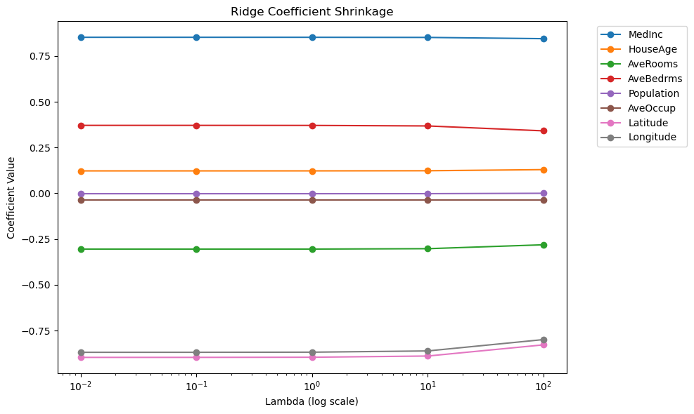

```python
from sklearn.linear_model import Ridge
lambdas = [0.01, 0.1, 1, 10, 100]
ridge_coefficients = []
ridge_metrics = []

# --- Apply Ridge Regression ---
# Train ridge for each of the lambda values & evaluate with metrics
for alpha in lambdas:
    ridge = Ridge(alpha=alpha)
    ridge.fit(x_train, y_train)
    y_pred = ridge.predict(x_test)

    ridge_coefficients.append(ridge.coef_)

    mse = mean_squared_error(y_test, y_pred)
    rmse = np.sqrt(mse)
    r2 = r2_score(y_test, y_pred)

    ridge_metrics.append({'Lambda': alpha, 'MSE': mse, 'RMSE': rmse, 'R2': r2})

ridge_metrics_df = pd.DataFrame(ridge_metrics)
display(ridge_metrics_df)

# Plot coeff shrinkage
plt.figure(figsize=(10, 6))
for i in range(features_scaled.shape[1]):
    plt.plot(lambdas, [coef[i] for coef in ridge_coefficients], marker='o', label=features_scaled.columns[i])
plt.xscale('log')
plt.xlabel('Lambda (log scale)')
plt.ylabel('Coefficient Value')
plt.title('Ridge Coefficient Shrinkage')
plt.legend(bbox_to_anchor=(1.05, 1), loc='upper left')
plt.tight_layout()
plt.show()
```

|  | Lambda | MSE | RMSE | R2 |
| --- | --- | --- | --- | --- |
| 0 | 0.01 | 0.547933 | 0.740225 | 0.581861 |
| 1 | 0.10 | 0.679552 | 0.824349 | 0.481420 |
| 2 | 1.00 | 1.310696 | 1.144856 | -0.000219 |
| 3 | 10.00 | 1.310696 | 1.144856 | -0.000219 |
| 4 | 100.00 | 1.310696 | 1.144856 | -0.000219 |

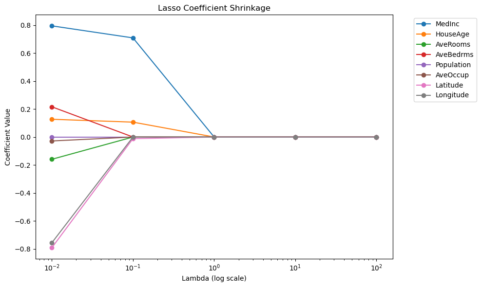

```python
# --- Apply Lasso Regression ---
from sklearn.linear_model import Lasso
lasso_coefficients = []
lasso_metrics = []

# Train Lasso for each lambda
for alpha in lambdas:
    lasso = Lasso(alpha=alpha, max_iter=10000)
    lasso.fit(x_train, y_train)
    y_pred = lasso.predict(x_test)

    lasso_coefficients.append(lasso.coef_)

    mse = mean_squared_error(y_test, y_pred)
    rmse = np.sqrt(mse)
    r2 = r2_score(y_test, y_pred)

    lasso_metrics.append({'Lambda': alpha, 'MSE': mse, 'RMSE': rmse, 'R2': r2})

lasso_metrics_df = pd.DataFrame(lasso_metrics)
display(lasso_metrics_df)

# Plot coeff shrinkage
plt.figure(figsize=(10, 6))
for i in range(features_scaled.shape[1]):
    plt.plot(lambdas, [coef[i] for coef in lasso_coefficients], marker='o', label=features_scaled.columns[i])
plt.xscale('log')
plt.xlabel('Lambda (log scale)')
plt.ylabel('Coefficient Value')
plt.title('Lasso Coefficient Shrinkage')
plt.legend(bbox_to_anchor=(1.05, 1), loc='upper left')
plt.tight_layout()
plt.show()
```

Lasso feature selection: Lasso set coefficients of Population to always be 0. At lambda = 0.1, AveRooms, AveBedrms, AveOccup, and Longitude are set to 0. At the next lambda value, all features coeffcients are set to 0. These are the features that Lasso eliminated.

### **4. Interpretation & Discussion (5 points)**

- **Compare and interpret results:**
  - How did Ridge and Lasso handle multicollinearity?
  - Which model had better predictive accuracy?
  - When would you use Ridge over Lasso (and vice versa)?
- **Discuss implications for real-world regression problems:**
  - If a model has too many irrelevant features, which method (Ridge or Lasso) would be more effective?
  - How does regularization impact overfitting in high-dimensional datasets?

Ridge and Lasso handle multicollinearity differently. Ridge works to reduce the magnitude of the feature coefficients but retains all of them. This spreads out the performance gains of the correlated features across them (which still makes interpretability a bit difficult). Lasso works to make the magnitude of certain features identically zero, effectively eliminating redundant features from the dataset. We saw this in the above analysis with Latitude and Longitude for example. Lasso correctly identified the multicollinearity between these features and removed Longitude from the feature set (by setting its coefficient to 0).

If a model has too many irrelevant features, I would use the Lasso method. This is becuse Lasso will identify those features that are not needed and set their coefficients/weights to 0, effectively removing them from the feature dataset.

Regularization impacts overfitting in high-dimensional datasetss by giving penalties to large/unnecessary feature coefficients. This helps to make the model more simple and can help it to genearlize better. Ridge regression shrinks the feature coefficients to reduce variance, and Lasso eliminates irrelevant features. Both methods reduce model complexity and improve stability, which helps the model to not memorize the training data and generalize to unseen data. The model is forced to generalize from less features, or weigh the features more conservatively.

# Q2: Supervised Learning Classification

## Breast Cancer Prediction Using Feature Engineering & SVM (40 points total)

In this question, you will build a classifier to predict the diagnosis of breast cancer (malignant vs. benign) using structured diagnostic data. You will preprocess features, engineer new ones, and evaluate multiple classification models, with a focus on implementing Support Vector Machines (SVMs) from scratch using quadratic programming.

## 1. Data Acquisition & Preprocessing (5 points)

- **Dataset**: Use the Breast Cancer Wisconsin (Diagnostic) Dataset) (also available via `sklearn.datasets.load_breast_cancer()`).

### Exploratory Data Analysis (EDA):

- Examine the distribution of the target variable (`diagnosis`: M = malignant, B = benign).
- Identify any missing or anomalous values.
- Explore relationships between features such as:
  - `mean radius`
  - `mean texture`
  - `mean smoothness`

### Feature Engineering:

- Encode the target variable (`diagnosis`) into binary:
  - `1 = malignant`, `0 = benign`
- Normalize continuous features using `StandardScaler` or `MinMaxScaler` (especially important for SVM).
- Create interaction terms or polynomial features (e.g., `mean radius × mean texture`, `mean concavity²`) using `PolynomialFeatures` from `sklearn.preprocessing`.

```
Number of Benign cases: 212
Number of Malignant cases: 357

Descriptive Stats:
```

|  | mean radius | mean texture | mean perimeter | mean area | mean smoothness | mean compactness | mean concavity | mean concave points | mean symmetry | mean fractal dimension | ... | worst texture | worst perimeter | worst area | worst smoothness | worst compactness | worst concavity | worst concave points | worst symmetry | worst fractal dimension | target |
| --- | --- | --- | --- | --- | --- | --- | --- | --- | --- | --- | --- | --- | --- | --- | --- | --- | --- | --- | --- | --- | --- |
| count | 569.000000 | 569.000000 | 569.000000 | 569.000000 | 569.000000 | 569.000000 | 569.000000 | 569.000000 | 569.000000 | 569.000000 | ... | 569.000000 | 569.000000 | 569.000000 | 569.000000 | 569.000000 | 569.000000 | 569.000000 | 569.000000 | 569.000000 | 569.000000 |
| mean | 14.127292 | 19.289649 | 91.969033 | 654.889104 | 0.096360 | 0.104341 | 0.088799 | 0.048919 | 0.181162 | 0.062798 | ... | 25.677223 | 107.261213 | 880.583128 | 0.132369 | 0.254265 | 0.272188 | 0.114606 | 0.290076 | 0.083946 | 0.627417 |
| std | 3.524049 | 4.301036 | 24.298981 | 351.914129 | 0.014064 | 0.052813 | 0.079720 | 0.038803 | 0.027414 | 0.007060 | ... | 6.146258 | 33.602542 | 569.356993 | 0.022832 | 0.157336 | 0.208624 | 0.065732 | 0.061867 | 0.018061 | 0.483918 |
| min | 6.981000 | 9.710000 | 43.790000 | 143.500000 | 0.052630 | 0.019380 | 0.000000 | 0.000000 | 0.106000 | 0.049960 | ... | 12.020000 | 50.410000 | 185.200000 | 0.071170 | 0.027290 | 0.000000 | 0.000000 | 0.156500 | 0.055040 | 0.000000 |
| 25% | 11.700000 | 16.170000 | 75.170000 | 420.300000 | 0.086370 | 0.064920 | 0.029560 | 0.020310 | 0.161900 | 0.057700 | ... | 21.080000 | 84.110000 | 515.300000 | 0.116600 | 0.147200 | 0.114500 | 0.064930 | 0.250400 | 0.071460 | 0.000000 |
| 50% | 13.370000 | 18.840000 | 86.240000 | 551.100000 | 0.095870 | 0.092630 | 0.061540 | 0.033500 | 0.179200 | 0.061540 | ... | 25.410000 | 97.660000 | 686.500000 | 0.131300 | 0.211900 | 0.226700 | 0.099930 | 0.282200 | 0.080040 | 1.000000 |
| 75% | 15.780000 | 21.800000 | 104.100000 | 782.700000 | 0.105300 | 0.130400 | 0.130700 | 0.074000 | 0.195700 | 0.066120 | ... | 29.720000 | 125.400000 | 1084.000000 | 0.146000 | 0.339100 | 0.382900 | 0.161400 | 0.317900 | 0.092080 | 1.000000 |
| max | 28.110000 | 39.280000 | 188.500000 | 2501.000000 | 0.163400 | 0.345400 | 0.426800 | 0.201200 | 0.304000 | 0.097440 | ... | 49.540000 | 251.200000 | 4254.000000 | 0.222600 | 1.058000 | 1.252000 | 0.291000 | 0.663800 | 0.207500 | 1.000000 |

8 rows × 31 columns

```
Missing Data:
```

```
mean radius                0
mean texture               0
mean perimeter             0
mean area                  0
mean smoothness            0
mean compactness           0
mean concavity             0
mean concave points        0
mean symmetry              0
mean fractal dimension     0
radius error               0
texture error              0
perimeter error            0
area error                 0
smoothness error           0
compactness error          0
concavity error            0
concave points error       0
symmetry error             0
fractal dimension error    0
worst radius               0
worst texture              0
worst perimeter            0
worst area                 0
worst smoothness           0
worst compactness          0
worst concavity            0
worst concave points       0
worst symmetry             0
worst fractal dimension    0
target                     0
dtype: int64
```

```
Explore Relationship Between Features:
```

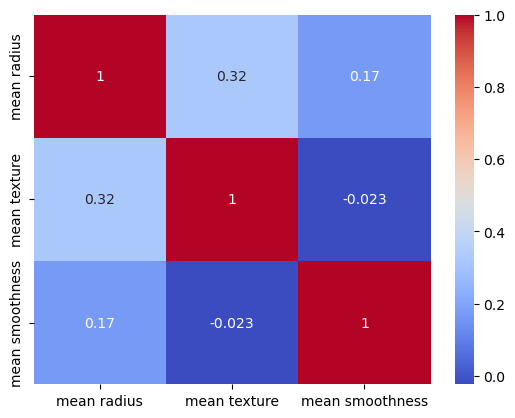

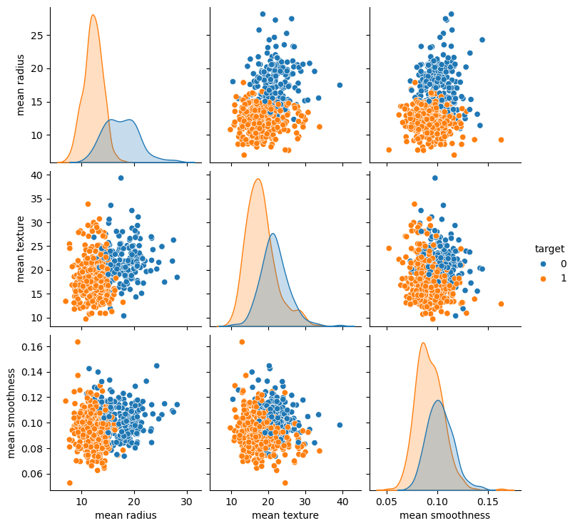

```
Interaction Features:
```

|  | mean radius | mean texture | mean concavity | mean radius^2 | mean radius mean texture | mean radius mean concavity | mean texture^2 | mean texture mean concavity | mean concavity^2 |
| --- | --- | --- | --- | --- | --- | --- | --- | --- | --- |
| 0 | 17.99 | 10.38 | 0.30010 | 323.6401 | 186.7362 | 5.398799 | 107.7444 | 3.115038 | 0.090060 |
| 1 | 20.57 | 17.77 | 0.08690 | 423.1249 | 365.5289 | 1.787533 | 315.7729 | 1.544213 | 0.007552 |
| 2 | 19.69 | 21.25 | 0.19740 | 387.6961 | 418.4125 | 3.886806 | 451.5625 | 4.194750 | 0.038967 |
| 3 | 11.42 | 20.38 | 0.24140 | 130.4164 | 232.7396 | 2.756788 | 415.3444 | 4.919732 | 0.058274 |
| 4 | 20.29 | 14.34 | 0.19800 | 411.6841 | 290.9586 | 4.017420 | 205.6356 | 2.839320 | 0.039204 |
| ... | ... | ... | ... | ... | ... | ... | ... | ... | ... |
| 564 | 21.56 | 22.39 | 0.24390 | 464.8336 | 482.7284 | 5.258484 | 501.3121 | 5.460921 | 0.059487 |
| 565 | 20.13 | 28.25 | 0.14400 | 405.2169 | 568.6725 | 2.898720 | 798.0625 | 4.068000 | 0.020736 |
| 566 | 16.60 | 28.08 | 0.09251 | 275.5600 | 466.1280 | 1.535666 | 788.4864 | 2.597681 | 0.008558 |
| 567 | 20.60 | 29.33 | 0.35140 | 424.3600 | 604.1980 | 7.238840 | 860.2489 | 10.306562 | 0.123482 |
| 568 | 7.76 | 24.54 | 0.00000 | 60.2176 | 190.4304 | 0.000000 | 602.2116 | 0.000000 | 0.000000 |

569 rows × 9 columns

```python
from sklearn.datasets import load_breast_cancer
from sklearn.preprocessing import PolynomialFeatures

# Load the data
breast_cancer_data = load_breast_cancer()

# Distribution of target
breast_cancer_df = pd.DataFrame(breast_cancer_data['data'], columns=breast_cancer_data['feature_names'])
breast_cancer_df['target'] = breast_cancer_data['target']

print(f"Number of Benign cases: {(breast_cancer_df.target==0).sum()}")
print(f"Number of Malignant cases: {(breast_cancer_df.target==1).sum()}\n")

# --- Exploratory Data Analysis ---
# Descriptive statistics and feature distributions
print("Descriptive Stats:")
display(breast_cancer_df.describe())

# Missing or anomalous values
print("Missing Data:")
display(breast_cancer_df.isna().sum())

# Relationship between features
print("Explore Relationship Between Features:")
relationship_features = ['mean radius', 'mean texture', 'mean smoothness', 'target']
corr_matrix = breast_cancer_df[relationship_features].drop(columns='target').corr()
sns.heatmap(corr_matrix, annot=True, cmap='coolwarm')
plt.show()

sns.pairplot(breast_cancer_df[relationship_features], hue='target', diag_kind='kde')
plt.show()


# --- Feature Engineering ---
# The target variable is already encoded as 0 and 1 for benign and malignant.
# Normalize features
features = breast_cancer_df.drop(columns='target')
targets = breast_cancer_df['target']
scaler = StandardScaler()
features_scaled = pd.DataFrame(scaler.fit_transform(features), columns=features.columns)

# Create interaction terms
interaction_feature_names = ['mean radius', 'mean texture', 'mean concavity']
interaction_features = features[interaction_feature_names]

poly = PolynomialFeatures(degree=2, include_bias=False, interaction_only=False)
features_poly = poly.fit_transform(interaction_features)
poly_feature_names = poly.get_feature_names_out(interaction_feature_names)

poly_features_df = pd.DataFrame(features_poly, columns=poly_feature_names)
print('Interaction Features:')
display(poly_features_df)

features_total = pd.concat([features_scaled, poly_features_df], axis=1)  # Include interaction terms into the total feature set
```

Above is an analysis that looks at the relationship between the mean radius, mean texture, and mean smoothness features in this dataset. From the correlation heatmap, we can see that these features are all weakly correlated with eachother, which means they won't provide redundant information to the model. Looking at the pair plot, we can see that the distributions of these features are different, and do appear to be separable. This checks out with the heatmap above it.

## 2. Model Training & Evaluation (20 points)

Train the following classifiers:

- **Logistic Regression** (baseline; use `scikit-learn`)
- **Decision Tree Classifier** (interpretable; use `scikit-learn`)
- **Support Vector Machine (SVM)**:
  - Implement from scratch using the `cvxopt` quadratic programming solver
  - Do **not** use `scikit-learn`'s `SVC` or `LinearSVC`

### Evaluation Metrics:

- Accuracy
- Precision
- Recall
- F1-Score
- Confusion Matrix
- ROC-AUC Curve

Use appropriate plots to visualize performance (e.g., confusion matrix heatmap, ROC curves).

```
--- Logistic Regression ---
Accuracy:
0.9825

Precision:
0.9859

Recall:
0.9859

F1-Score:
0.9859

Confusion Matrix:
[[42  1]
 [ 1 70]]

ROC AUC Score:
0.9813


--- Decision Tree ---
Accuracy:
0.9561

Precision:
0.9583

Recall:
0.9718

F1-Score:
0.9650

Confusion Matrix:
[[40  3]
 [ 2 69]]

ROC AUC Score:
0.9510
```

[output cut: 19 more lines]

```
Precision:
0.9859

Recall:
0.9859

F1-Score:
0.9859

Confusion Matrix:
[[42  1]
 [ 1 70]]

ROC AUC Score:
0.9813
```

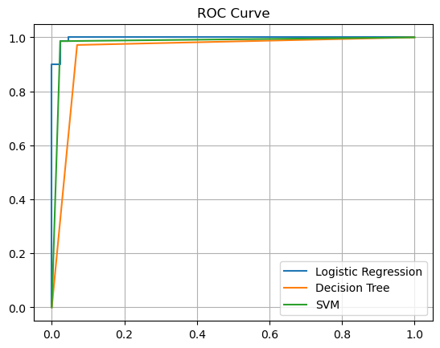

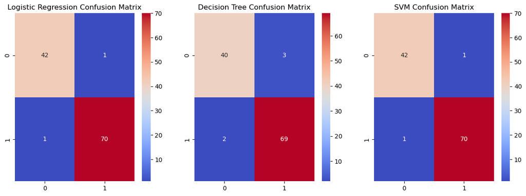

```python
from sklearn.linear_model import LogisticRegression
from sklearn.tree import DecisionTreeClassifier
from cvxopt import matrix, solvers
from sklearn.metrics import accuracy_score, precision_score, recall_score, f1_score, confusion_matrix, roc_auc_score, roc_curve

def get_metrics(y_true, y_pred):
    print(f"Accuracy:\n{accuracy_score(y_true, y_pred):.4f}\n")
    print(f"Precision:\n{precision_score(y_true, y_pred):.4f}\n")
    print(f"Recall:\n{recall_score(y_true, y_pred):.4f}\n")
    print(f"F1-Score:\n{f1_score(y_true, y_pred):.4f}\n")
    print(f"Confusion Matrix:\n{confusion_matrix(y_true, y_pred)}\n")
    print(f"ROC AUC Score:\n{roc_auc_score(y_true, y_pred):.4f}\n\n")
    return confusion_matrix(y_true, y_pred)


X_train, X_test, y_train, y_test = train_test_split(features_total, targets, test_size=0.2, random_state=42)

# --- Logistic Regression ---
print('--- Logistic Regression ---')
lr_model = LogisticRegression(max_iter=10000)
lr_model.fit(X_train, y_train)

y_pred_lr_proba = lr_model.predict_proba(X_test)[:, 1]
y_pred_lr = lr_model.predict(X_test)

cf_lr = get_metrics(y_test, y_pred_lr)
fpr_lr, tpr_lr, thresh_lr = roc_curve(y_test, y_pred_lr_proba)

# --- Decision Tree ---
print('--- Decision Tree ---')
dt_model = DecisionTreeClassifier()
dt_model.fit(X_train, y_train)

y_pred_dt_proba = dt_model.predict_proba(X_test)[:, 1]
y_pred_dt = dt_model.predict(X_test)

cf_dt = get_metrics(y_test, y_pred_dt)
fpr_dt, tpr_dt, thresh_dt = roc_curve(y_test, y_pred_dt_proba)

# --- SVM ---
def linear_kernel(X1, X2):
    return np.dot(X1, X2.T)

def rbf_kernel(X1, X2, gamma):
    sq_dists = np.sum(X1**2, axis=1)[:, np.newaxis] + np.sum(X2**2, axis=1) - 2 * np.dot(X1, X2.T)
    return np.exp(-gamma * sq_dists)

def train_svm(X, y, kernel='linear', gamma=1.0):
    X = np.array(X)
    y = np.array(y)

    n_samples, n_features = X.shape

    # K = np.dot(X, X.T)
    if kernel == "linear":
        K = linear_kernel(X, X)
    elif kernel == "rbf":
        K = rbf_kernel(X, X, gamma)
    else:
        raise ValueError("Unsupported kernel")
    P = matrix(np.outer(y, y) * K)
    q = matrix(-np.ones(n_samples))

    # Constraining inequality matrices
    C = 1.0
    G = matrix(np.vstack((-np.eye(n_samples), np.eye(n_samples))))
    h = matrix(np.hstack((np.zeros(n_samples), np.ones(n_samples) * C)))

    # Equality constraint matrices
    A = matrix(y.reshape(1, -1).astype('double'))
    b = matrix(np.zeros(1))

    solution = solvers.qp(P, q, G, h, A, b)
    alphas = np.array(solution['x']).flatten()

    support_vectors = alphas > 1e-5
    support_vector_indices = np.where(support_vectors)[0]
    alpha_sv = alphas[support_vectors]
    X_sv = X[support_vectors]
    y_sv = y[support_vectors]

    # Weights and biases
    w = np.sum(alpha_sv[:, None] * y_sv[:, None] * X_sv, axis=0)

    # Compute bias (use first support vector)
    b = np.mean(y_sv - np.dot(X_sv, w))

    return w, b, support_vector_indices


def predict_svm(X, w, b):
    return np.sign(np.dot(X, w) + b)


print("--- SVM ---")
y_train_svm = np.where(y_train==0, -1, 1)
y_test_svm = np.where(y_test==0, -1, 1)

w, b, support_vector_indices = train_svm(X_train, y_train_svm)
y_pred_svm = predict_svm(X_test, w, b)

cf_svm = get_metrics(y_test_svm, y_pred_svm)
fpr_svm, tpr_svm, thresh_svm = roc_curve(y_test_svm, y_pred_svm)


# ROC Curves
plt.plot(fpr_lr, tpr_lr, label='Logistic Regression')
plt.plot(fpr_dt, tpr_dt, label='Decision Tree')
plt.plot(fpr_svm, tpr_svm, label='SVM')
plt.title('ROC Curve')
plt.legend(loc='lower right')
plt.grid(True)
plt.show()

# Confusion Matrix Heat Maps
fig, axes = plt.subplots(nrows=1, ncols=3, figsize=(15, 5))

sns.heatmap(cf_lr, annot=True, cmap='coolwarm', ax=axes[0])
axes[0].set_title('Logistic Regression Confusion Matrix')

sns.heatmap(cf_dt, annot=True, cmap='coolwarm', ax=axes[1])
axes[1].set_title('Decision Tree Confusion Matrix')

sns.heatmap(cf_svm, annot=True, cmap='coolwarm', ax=axes[2])
axes[2].set_title('SVM Confusion Matrix')

plt.show()
```

## 3. Hyperparameter Tuning (10 points)

### Hyperparameter Tuning:

- **Logistic Regression**: Tune regularization parameter `C`
- **Decision Tree**: Tune `max_depth` and optionally `min_samples_leaf`
- **SVM**: Try both linear and RBF kernels (implement both kernels)
  - Linear Kernel - $K(x,x') = x^T x' $
  - RBF kernel - $K(x,x') = \exp(-\gamma || x - x' ||^2)$
    - where $\gamma > 0$ is a parameter that defines the spread of the kernel

```python
from sklearn.model_selection import GridSearchCV

# Logistic Regression
C_values = [0.001, 0.01, 0.1, 1, 10, 100]
parameter_grid_lr = {
    'C': [0.001, 0.01, 0.1, 1, 10, 100],
    'penalty': ['l1', 'l2'],
    'solver': ['liblinear'],
}
grid_search_lr = GridSearchCV(LogisticRegression(max_iter=10000), parameter_grid_lr, cv=5, scoring='accuracy')
grid_search_lr.fit(X_train, y_train)
print(f"--- Logistic Regression ---\nBest parameters: {grid_search_lr.best_params_}")
print(f"Best score: {grid_search_lr.best_score_}\n")


# Decision Tree
parameter_grid_dt = {
    'max_depth': [None, 5, 10, 15, 20],  # None = no limit on depth
    'min_samples_leaf': [1, 5, 10, 20, 50]
}
grid_search_dt = GridSearchCV(DecisionTreeClassifier(), parameter_grid_dt, cv=5, scoring='accuracy')
grid_search_dt.fit(X_train, y_train)
print(f"--- Decision Tree ---\nBest parameters: {grid_search_dt.best_params_}")
print(f"Best score: {grid_search_dt.best_score_}\n")


# Support Vector Machine
#    I added in the code updates for these 2 kernel (linear and RBF) to my SVM funciton definition in the previous section. I'll implement them here:
print("--- Support Vector Machine ---")
w, b, support_vector_indices = train_svm(X_train, y_train_svm, kernel='linear')
y_pred_svm_linear = predict_svm(X_test, w, b)

w, b, support_vector_indices = train_svm(X_train, y_train_svm, kernel='rbf')
y_pred_svm_rbf = predict_svm(X_test, w, b)

cf_svm_linear = get_metrics(y_test_svm, y_pred_svm_linear)
cf_svm_rbf = get_metrics(y_test_svm, y_pred_svm_rbf)
```

```
--- Logistic Regression ---
Best parameters: {'C': 10, 'penalty': 'l2', 'solver': 'liblinear'}
Best score: 0.9780219780219781

--- Decision Tree ---
Best parameters: {'max_depth': None, 'min_samples_leaf': 10}
Best score: 0.945054945054945

--- Support Vector Machine ---
     pcost       dcost       gap    pres   dres
 0: -8.6410e+01 -9.8878e+02  5e+03  3e+00  2e-09
 1: -5.5510e+01 -5.8409e+02  1e+03  4e-01  1e-09
 2: -3.6683e+01 -2.8842e+02  4e+02  1e-01  9e-10
 3: -2.4695e+01 -1.4926e+02  2e+02  6e-02  7e-10
 4: -1.9442e+01 -7.1031e+01  9e+01  2e-02  6e-10
 5: -1.6546e+01 -2.9747e+01  2e+01  4e-03  5e-10
 6: -1.7044e+01 -2.0785e+01  5e+00  7e-04  5e-10
 7: -1.7674e+01 -1.8266e+01  6e-01  2e-05  6e-10
 8: -1.7907e+01 -1.7925e+01  2e-02  4e-07  6e-10
 9: -1.7914e+01 -1.7915e+01  6e-04  1e-08  7e-10
10: -1.7914e+01 -1.7914e+01  7e-06  1e-10  6e-10
Optimal solution found.
     pcost       dcost       gap    pres   dres
 0: -1.8885e+02 -7.5903e+02  6e+02  7e-15  3e-16
 1: -1.9592e+02 -2.2102e+02  3e+01  2e-14  2e-16
 2: -2.0337e+02 -2.0396e+02  6e-01  1e-14  1e-16
 3: -2.0357e+02 -2.0357e+02  6e-03  6e-15  9e-17
 4: -2.0357e+02 -2.0357e+02  6e-05  4e-15  5e-17
Optimal solution found.
Accuracy:
0.9825

Precision:
0.9859

Recall:
0.9859

F1-Score:
0.9859
```

[output cut: 12 more lines]

```
Precision:
0.9167

Recall:
0.7746

F1-Score:
0.8397

Confusion Matrix:
[[38  5]
 [16 55]]

ROC AUC Score:
0.8292
```

## 4. Interpretation & Discussion (5 points)

### Model Comparison:

- Which model performed best overall?
- Which model showed the most stability (i.e., smallest performance variance across folds)?
- How did kernel choice in SVM influence classification performance?
- Did feature scaling or polynomial features help the SVM?

### Real-World Implications:

- What are the consequences of **false negatives** in this breast cancer prediction task?
- In a medical diagnosis context, would you prioritize **precision** or **recall**? Why?
- Is your SVM implementation viable for use in clinical decision-making tools? What improvements would be necessary?

## Submission Guidelines:

- Submit a Jupyter notebook (or `.py` script) with all code and plots
- Include a brief summary of findings at the end of the notebook
- Code should be clearly commented and structured

## Optional Extensions:

- Implement grid search manually for SVM kernel and `C` tuning
- Use SHAP or LIME for post hoc model explanation (especially for the logistic model)

**Model Comparison**  
The best performing models were Logistic Regression and Linear-Kernel SVM. They produced about the same values for accuracy, precision, recall, F1-score, and ROC AUC score. They likely learned the same linear decision boundary. Based on this analysis, the Logistic Regression has the most stability. The performance of SVM is dependent on the kernel choice. The kernel choice for the SVM did affect the classification performance. In this case, the linear kernel led to better performance than the rbf kernel. The linear kernel model had better accuracy, precision, recall, F1-score, and ROC AUC score compared to the rbf kernel model. In this case, the feature scaling definitely helped the SVM as it eliminates the risk that features with a large range will dominate and impact the learned decision boundary. Given the success of the linear model, I would say that the polynomial features were less significant to the performance of the model.

**Real-World Implications** False-negatives in this breast cancer prediction task mean malignant (cancerous) tumors were classified as benign. THis has huge implications for the health and prognosis of the patient as a missed cancer diagnosis can result in the cancer growing to be larger, more aggressive, and may become life threatening to the person. In the context of this medical diagnosis, I would prioritize Recall. Recall is the proportion of correctly predicted positive instances out of all actual positive instances. In the case of cancer detection, we want to correctly predict as many positive instances as possible. High recall = detecting as many true cancer cases as possible. False positives here are less harmful than false negatives. My SVM in its current state is not viable for use in clinical decision-making. For it to be viable, I would make sure to include probabalistic outputs and cross validation to make sure that the best model is produced. Also, I would want to evaluate the fairness/bias within the datasets, again to make sure that the model is general. Also, I would want to make sure that this SVM is clearly intepretable before deploying it.

# **Q3: Custom K-Means Clustering Framework**

## Build a custom K-Means clustering framework from scratch (scikit-learn not permitted) (30 points total)

In this question, you will implement the K-Means clustering algorithm from scratch and develop a framework that evaluates multiple candidate numbers of clusters. You will apply your framework to the **Wholesale Customers Dataset** from the UCI Machine Learning Repository, which is well-suited for clustering-based customer segmentation. **Note:** For the clustering analysis, you should drop the **Channel** and **Region** columns, focusing solely on the spending features. Additionally, you will analyze the runtime of your algorithm and provide an asymptotic complexity analysis.

### **1. Data Acquisition & Preprocessing (5 points)**

- **Dataset:** Download the **Wholesale Customers Dataset** from the UCI Machine Learning Repository.
- **Exploratory Data Analysis (EDA):**
  - Identify missing or inconsistent values.
  - Analyze the distributions of features.
  - Apply normalization or standardization if necessary to ensure the data is suitable for clustering.
  - **Important:** Remove the **Channel** and **Region** columns before performing clustering analysis.

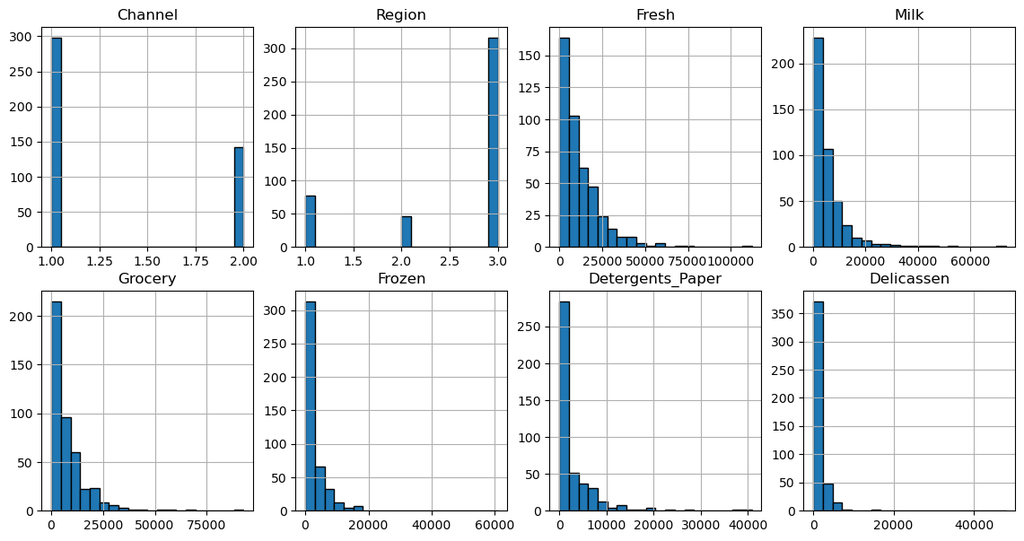

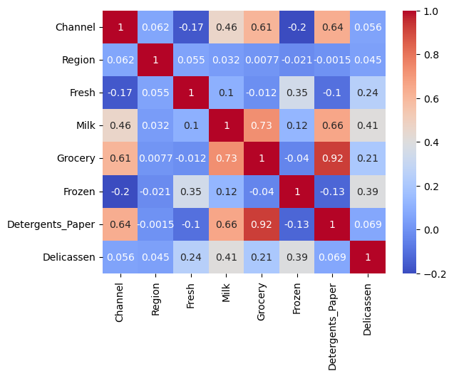

```
Cleaned Data:
```

|  | Fresh | Milk | Grocery | Frozen | Detergents_Paper | Delicassen |
| --- | --- | --- | --- | --- | --- | --- |
| 0 | 0.112940 | 0.130727 | 0.081464 | 0.003106 | 0.065427 | 0.027847 |
| 1 | 0.062899 | 0.132824 | 0.103097 | 0.028548 | 0.080590 | 0.036984 |
| 2 | 0.056622 | 0.119181 | 0.082790 | 0.039116 | 0.086052 | 0.163559 |
| 3 | 0.118254 | 0.015536 | 0.045464 | 0.104842 | 0.012346 | 0.037234 |
| 4 | 0.201626 | 0.072914 | 0.077552 | 0.063934 | 0.043455 | 0.108093 |

```python
import kagglehub
from sklearn.preprocessing import MinMaxScaler

# Download
path = kagglehub.dataset_download("binovi/wholesale-customers-data-set")
print("Path to dataset files:", path)
data = pd.read_csv(f'{path}/Wholesale customers data.csv')

# Check for missing data
print("Missing Data:")
print(data.isna().sum())

# Summary Statistics
print("\nSummary Statistics:")
data.describe()

# Distributions
fig, axes = plt.subplots(nrows=2, ncols=4, figsize=(14,7))
axes = axes.flatten()
for i, column in enumerate(data.columns):
    if i < len(axes):
        data[column].hist(ax=axes[i], bins=20, edgecolor='black')
        axes[i].set_title(f'{column}')
plt.show()

corr_matrix = data.corr()
sns.heatmap(corr_matrix, annot=True, cmap='coolwarm')
plt.show()
# Normalization & Remove Channel and Region columns
print('\nCleaned Data:')
scaler = MinMaxScaler()
data_normalized = pd.DataFrame(scaler.fit_transform(data), columns=data.columns).drop(columns=['Channel', 'Region'])
data_normalized.head()
```

[output not shown]

In this dataset, there are 8 numeric variables. None of them have missing data. Most of the features are right skewed and do not follow a normal distribution. From the corrrelation heat map we can see that the features are largely uncorrelated. The highest correlated features are Grocery and Detergents_Paper with a correlation coefficient of 0.92. Milk and Detergents_Paper, and Milk and Grocery are also correlated, with correlation coefficients of around 0.7.

### **2. Problem Formulation & Algorithm Design (10 points)**

- **Objective:** Clearly define the goal of clustering in the context of customer segmentation using the Wholesale Customers dataset.
- **Algorithm Overview:**
  - Provide a brief explanation of the K-Means clustering algorithm, detailing its main steps:
    - **Initialization:** Selecting initial centroids.
    - **Assignment:** Allocating data points to the nearest centroid.
    - **Update:** Recalculating centroids based on the current cluster members.
- **Framework Requirements:**
  - Develop a framework that accepts a list of candidate numbers of clusters (e.g., [2, 3, 4, 5, 6]).
  - For each candidate value, run your custom K-Means algorithm.
  - Compute clustering metrics (such as Within-Cluster Sum of Squares (WCSS) and silhouette score—metrics introduced in lecture) for each clustering result.
  - Select and justify the best number of clusters based on your computed metrics.
- **Considerations:**
  - Discuss any assumptions you make (e.g., initialization methods, convergence criteria).
  - Identify potential challenges in applying K-Means to this dataset.

My responses:

**Objective**:  
The goal of clustering in this context is to group the wholesale customers into distinct groups/segments based on their annual spending in different product categories (e.g., fresh, milk, grocery, frozen, etc.). This grouping can be helpful to businesses. It can allow them to gain an understanding of who their customers are, and can tailor marketing strategies, and give personalized services/experiences to them.

**Algorithm Overview**:  
K-Means splits the data into K distinct clusters. The algorithm minimizes the Within-Cluster Sum of Squares (WCSS).  
Algorithm Steps:

1. Initialization - Randomly select K data points as initial cluster centroids.
2. Assignment - Assign each data point to the nearest centroid based on Euclidean distance.
3. Update - Recompute the centroids' positions by averaging all points in each cluster.
4. Repeat this process until the cluster centroids and assignments no longer change or if a maximum number of iterations is reached.

**Framework**  
(Code is in the next section)  
To accomplish the goals and encompass the requirements for this Framework, I would develop a wrapper function that would accept the input data to be clustered and the list of different k values to be tried. Within that wrapper function, it would loop through each k-value and run the k-means algorithm that I wrote (wihtout the use of sklearn). Within the loop, I would then compute the custering metrics for that k-valued k-means run. I would then append the WCSS and silhouette scores to an output results data structure (I think a dictionary or pd.DataFrame would work well) that clearly shows the WCSS and Silhouette Score for each K-value that was inputted.

PseudoCode:

```
{python}
for k in k_values:
    run_k_means(input_data, k)
    evaluate_WCSS()
    evaluate_silhouette_score()
    append WCSS, Silhouette Score, and K-vlaue to result structure
```

After running this, I would then analyze the WCSS values and Silhouette scores to determine which K-value is optimal. I would look for maximal Silhouette score with minimal WCSS value.

**Considerations**  
For initialization, the cluster centroids are assigned randomly. This can lead to sub-optimal clustering if poor initial centroids are selected.

The algorithm stops running when the centroids no longer move significantly or after reaching a maximum number of iterations. This assumes that the convergence will lead to a good local minimum. It does not guarantee that the global optimum is found.

K-means uses Euclidean distance as to define the similarity between data points. This inherently assumes that the clusters will be spherical and equally sized. This assumption may not hold/be accurate in real-world scenarios.

This algorithm also assumes that input data has been normalized or standardized. This is becausue the Euclidean distance is sensitive to feature magnitude. Without scaling, features with larger numeric ranges could significantly affect the outcome of the clustering.

### **3. Implementation & Runtime Analysis (10 points)**

- **Implementation:**
  - Write your own implementation of the K-Means algorithm in Python without using any built-in clustering libraries.
  - Integrate the algorithm into a framework that automates the process for multiple candidate numbers of clusters.
- **Runtime Analysis:**
  - Measure and report the total runtime of your algorithm for different candidate values.
  - Analyze the computational complexity of your implementation. Provide the asymptotic notation (e.g., O(n × k × i)), where:
    - *n* is the number of data points,
    - *k* is the number of clusters,
    - *i* is the number of iterations until convergence.
- **Documentation:**
  - Ensure your code is well-documented, with comments explaining the functionality of key components.

```python
from sklearn.metrics import silhouette_score
import time

def compute_euclidean_distances(X, centroids):
    """Calculation for Eculidean Distance between data points and cluster centroids.

    Args:
        X (ArrayLike): Input data to cluster.
        centroids (_type_): Centroids

    Returns:
        _type_: Distances to centroids.
    """
    distances = np.zeros((X.shape[0], centroids.shape[0]))
    for i, centroid in enumerate(centroids):
        distances[:, i] = np.sqrt(np.sum((X - centroid)**2, axis=1))
    return distances


def kmeans(X, k, max_iters=100, tol=1e-4):  # O(i * n * k * d) where d is # of features/dimensions
    """Kmeans clustering algorithm without sklearn

    Args:
        X (ArrayLike): Input data of shape (n_samples, n_features).
        k (int): Number of clusters.
        max_iters (int, optional): Max number of iterations. Defaults to 100.
        tol (float, optional): Shift tolerance for convergence. Defaults to 1e-4.

    Returns:
        labels (ndarray): Cluster assignment for each datapoint.
        centroids (ndarray): Centroid location.
    """
    X = np.array(X)

    np.random.seed(42)  # Set random seed
    n_samples, n_features = X.shape

    # Initialization - randomly place centroids
    centroids = X[np.random.choice(n_samples, k, replace=False)]  # O(k)

    for i in range(max_iters):  # Iterate for max_iters, unless convergence
        # Assignment  O(n * k * d)
        distances = compute_euclidean_distances(X, centroids)
        labels = np.argmin(distances, axis=1)

        # Update  O(n * d)
        new_centroids = np.array([X[labels == i].mean(axis=0) for i in range(k)])
        shift = np.linalg.norm(new_centroids - centroids)

        if shift < tol:
            break  # Terminate if tolerance condition met for convergence
        centroids = new_centroids

    return labels, centroids



def compute_wcss(X, labels, centroids):
    """Computes Within Cluster Sum of Squares (WCSS)

    Args:
        X (ArrayLike): Input data of shape (n_samples, n_features).
        labels (ndarray): Cluster assignment for each datapoint.
        centroids (ndarray): Centroid location.

    Returns:
        wcss (float): Sum of the squared distances within clusters
    """
    return sum(np.linalg.norm(X[labels == i] - centroids[i], axis=1).sum() for i in range(len(centroids)))


def evaluate_clusters(X, k_values):
    """Framework that runs K-means for given k_values and computes evaluation metrics.

    Args:
        X (ArrayLike): Input data of shape (n_samples, n_features).
        k_values (list): List of cluster counts.

    Returns:
        results (list of dict): For each k, stores WCSS and silhouette score
    """
    results = []
    for k in k_values:
        time_start = time.time()
        labels, centroids = kmeans(X, k)
        wcss = compute_wcss(X, labels, centroids)
        silhouette = silhouette_score(X, labels) if k > 1 else np.nan
        time_end = time.time()
        results.append({'k': k, 'wcss': wcss, 'silhouette': silhouette, 'time_s': time_end-time_start})
    return results


# Run K-means on various candidate clusters
candidate_clusters = [2, 3, 4, 5, 6]
results = evaluate_clusters(data_normalized, candidate_clusters)
print("Results:")
pd.DataFrame(results)
```

```
Results:
```

|  | k | wcss | silhouette | time_s |
| --- | --- | --- | --- | --- |
| 0 | 2 | 66.665597 | 0.570760 | 0.018342 |
| 1 | 3 | 59.284742 | 0.368294 | 0.036822 |
| 2 | 4 | 51.967243 | 0.402494 | 0.006665 |
| 3 | 5 | 48.571611 | 0.297491 | 0.010845 |
| 4 | 6 | 47.175928 | 0.349679 | 0.028153 |

The total runtime for each of the candidate clusters is shown above. K=4 ran in the least amount of time.

### **4. Evaluation & Reflection (5 points)**

- **Result Comparison:**
  - Compare the clustering results obtained for each candidate number of clusters using your chosen metrics.
  - Identify which number of clusters produced the best overall performance.
- **Discussion:**
  - Analyze how the resultant clusters relate back to the physical world. For example, interpret the clusters in terms of customer segmentation by exploring patterns such as purchasing behavior, spending habits, or other relevant characteristics.
  - Discuss what the cluster profiles might imply for real-world applications, such as targeted marketing strategies or business decision-making.
  - Reflect on the trade-offs between clustering quality and runtime performance.

This question is designed to deepen your understanding of unsupervised learning, algorithm development, and performance evaluation. Be sure to clearly justify your design choices and critically analyze your results throughout the report.

**Result Comparison**  
Based on the evaluation metrics shown above, the optimal number of clusters appears to be k = 2. This amount of clusters produced the highest silhouette score of 0.571, which indicates that the clusters are well-separated. Although the WCSS is not a minimum at k = 2, the largest improvement occurs between k = 2 and k = 3 (with continued small decreases as more clusters are addede). While k = 4 shows a slight increase in silhouette score and continued WCSS reduction, the overall quality of clustering is strongest at k = 2. This indicates that selecting 2 clusters gives the best performance.

**Discussion**  
The clusters derived here can be interpreted as distinct customer segments based on their spending across different product categories such as Fresh, Milk, Grocery, Frozen, Detergents_Paper, and Delicatessen. As an example, one cluster may represent small retailers or cafes that purchase moderately across all categories, while the other cluster may be larger companies with higher expenditures, especially in categories like Fresh and Frozen foods (I’m thinking something like a hotel or very large business).

Understanding these clusters and their behaviors can give value in real-world applications. Businesses could use this insight to tailor marketing strategies—for example, the businesses can provide bulk discounts or loyalty programs to buyers who purchase in large volume, or they can give cost-effective bundles or delivery services to the lower-volume customers. Additionally, by understanding the purchasing patterns of customers in each cluster, managing inventory and predicting sales can be optimized or improved.